# Analysis of Maternal plasma cell-free RNA sequencing for preeclamptic and normotensive mothers

Estefania Mancini

2022-10-11

# Data description

Liquid biopsies that measure circulating cell-free RNA (cfRNA) offer an unprecedented opportunity to noninvasively study the development of pregnancy-related complications and to bridge gaps in clinical care. Here, we sequenced cfRNA from 404 blood plasma samples (199 pregnant mothers) to identify and validate cfRNA transcriptomic changes that are associated with preeclampsia (PE), a multi-organ syndrome which is the second largest cause of maternal death globally. For each individual, samples were collected at one or more timepoints across gestation. For some, samples were also collected at least once post-partum

source https://www.nature.com/articles/s41586-022-04410-z

```r
sra<- read.csv("SraRunTable.txt")
sra[1:5,1:5]
```

```
##           Run                   Age Assay.Type AvgSpotLen       Bases
## 1 SRR17332994 11 weeks of gestation    RNA-Seq        150  9514437600
## 2 SRR17332995 11 weeks of gestation    RNA-Seq        150  6644869350
## 3 SRR17332997 19 weeks of gestation    RNA-Seq        150 13654380750
## 4 SRR17332999 12 weeks of gestation    RNA-Seq        150  6920686500
## 5 SRR17333000 12 weeks of gestation    RNA-Seq        150  6981052050
```

```r
colnames(sra)
```

```
##  [1] "Run"                  "Age"                  "Assay.Type"
##  [4] "AvgSpotLen"           "Bases"                "BIOMATERIAL_PROVIDER"
##  [7] "BioProject"           "BioSample"            "BioSampleModel"
## [10] "Bytes"                "Center.Name"          "Consent"
## [13] "DATASTORE.filetype"   "DATASTORE.provider"   "DATASTORE.region"
## [16] "Experiment"           "Instrument"           "Isolate"
## [19] "Library.Name"         "LibraryLayout"        "LibrarySelection"
## [22] "LibrarySource"        "Organism"             "Platform"
## [25] "ReleaseDate"          "Sample.Name"          "sex"
## [28] "SRA.Study"            "Tissue"               "disease"
```

```r
dim(sra)
```

```
## [1] 404  30
```

## Some categorical variables

```r
data <- data.frame(table(sra$Age))
head(data)
```

```
##                    Var1 Freq
## 1   0 weeks post-partum   44
## 2 0.5 weeks post-partum    1
## 3   1 weeks post-partum   18
## 4 10 weeks of gestation   19
## 5 11 weeks of gestation   46
## 6 12 weeks of gestation   29
```

```r
dataSex<-data.frame(table(sra$sex))
head(dataSex)
```

```
##     Var1 Freq
## 1 female  404
```

```r
table(sra$Tissue)
```

```
##
## blood plasma
##          404
```

```r
dataDisease<-data.frame(table(sra$disease))
head(dataDisease)
```

```
##                   Var1 Freq
## 1                       287
## 2        pre-eclampsia   60
## 3 severe pre-eclampsia   57
```

# Download data

To retrieve the data from SRA to our instance in AWS, there are some options

## Classical approach: using sratoolkit

source: https://github.com/ncbi/sra-tools

```bash
wget https://ftp-trace.ncbi.nlm.nih.gov/sra/sdk/current/sratoolkit.current-centos_linux64.tar.gz
 tar -zxf sratoolkit.current-centos_linux64.tar.gz

export PATH=$PATH:$PWD/sratoolkit.3.0.0-centos_linux64/bin
```

### Configure vdb

```bash
vdb-config --interactive
```

Source: https://github.com/ncbi/sra-tools/wiki/05.-Toolkit-Configuration

### Test

```bash
fastq-dump --stdout -X 2 SRR390728
```

### Option more efficient:

Launch using tmux:

```bash
tmux
```

```bash
prefetch SRR17332994
```

1 sample: 1 minute

```bash
fastq-dump --outdir fastq --gzip --skip-technical  --readids --read-filter pass --dumpbase --split-3 --clip SRR17332994 &
```

## Accessing SRA Data in AWS

- https://www.ncbi.nlm.nih.gov/sra/docs/sra-aws-download/
- https://s3.console.aws.amazon.com/s3/buckets/sra-pub-src-2/?region=us-east-1&tab=objects

To download files from the AWS Console using a browser, visit the HTTPS URL for the Coronaviridae dataset, Public SRA data, or Public user-submitted files respectively:

- https://s3.console.aws.amazon.com/s3/buckets/sra-pub-sars-cov2/
- https://s3.console.aws.amazon.com/s3/buckets/sra-pub-run-odp/
- https://s3.console.aws.amazon.com/s3/buckets/sra-pub-src-2/

From there you can navigate the directory structure using the provided graphical interface and you can search a given directory for your accession of interest using the provided search box near the top of the page. Once you have navigated to a specific file of interest you can click the Object URL link or use the Object actions button to copy the file to your own S3 bucket or download a copy to local storage.

These data can also be accessed using various other tools and libraries. Access to files in the AWS Registry of Open Data is free. This is true whether you use the HTTPS or S3 URL. For S3 URLs, the transfer is free even if it crosses an AWS region boundary; there is no inter-regional data transfer fee.

If you don’t know the Run accessions you are interested in, you can start by searching in the SRA Run Selector, AWS Athena, or SRA Entrez.

## Copying from SRA S3 Bucket

### Already created instance:

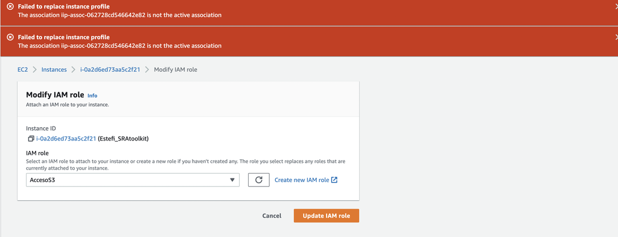

config

```bash
aws s3 ls s3://sra-pub-sars-cov2/

aws s3 cp s3://sra-pub-sars-cov2/README.txt

aws s3 ls s3://sra-pub-run-odp/sra/SRR17333143/SRR17333143
```

Could not connect to the endpoint URL: “https://sra-pub-run-odp.s3.EU.amazonaws.com/?list-type=2&delimiter=%2F&prefix=sra%2FSRR17333143%2FSRR17333143&encoding-type=url”

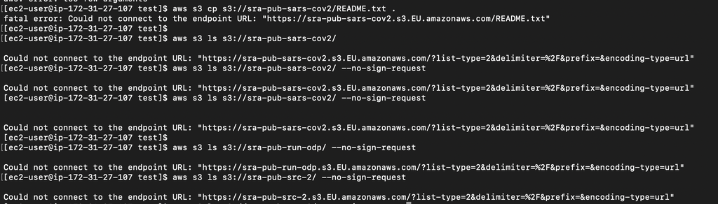

error1

## New instance

- Configure the IAM Instance Profile to “AccesoS3” before launching

```bash
aws s3 ls s3://sra-pub-sars-cov2/

aws s3 cp s3://sra-pub-sars-cov2/README.txt

aws s3 ls s3://sra-pub-run-odp/sra/SRR17333143/SRR17333143
```

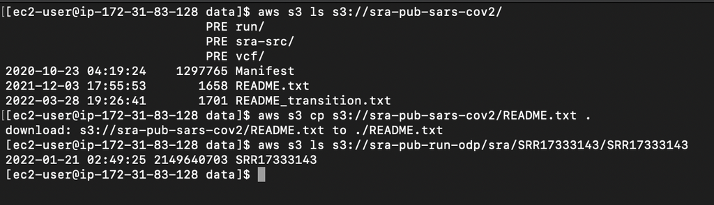

new

```bash
aws s3 cp s3://sra-pub-run-odp/sra/SRR17332994/SRR17332994 .
```

**download: s3://sra-pub-run-odp/sra/SRR17332994/SRR17332994 to ./SRR17332994**

1 minute

Then, we prepare extract files:

```bash
fastq-dump --outdir fastq --gzip --skip-technical  --readids --read-filter pass --dumpbase --split-3 --clip SRR17332994 &
```

Using prefetch:

```bash
prefetch SRR17332994

fastq-dump --outdir fastq --gzip --skip-technical  --readids --read-filter pass --dumpbase --split-3 --clip SRR17332994 &
```

- fastq-dump spends ~50 minutes for conversion

## What next?

Which is the best strategy for proccessing ~400 samples

# Quality control

## Fastqc

- Installation
- https://www.bioinformatics.babraham.ac.uk/projects/fastqc/
- We should install JAVA first. Any clue?

```bash
 sudo yum install java-1.8.0-openjdk-devel
```

Then we get fastqc:

```bash
wget https://www.bioinformatics.babraham.ac.uk/projects/fastqc/fastqc_v0.11.9.zip

chmod ug+x fastqc
export PATH=$PATH:/home/ec2-user/software/FastQC/
```

- Run

```bash
fastqc  sample.fq
```

## MultiQC

Build a report to visualize raw data

To install MultiQC, simply run pip install multiqc on the command line. If you use conda, you can run conda install -c bioconda multiqc instead. See the installation instructions for more help.

```bash
sudo yum install epel-release
sudo amazon-linux-extras install epel
sudo yum install python-pip
pip3 install multiqc
```

Finally run MultiQC on our samples:

```bash
 multiqc -p dataFetch/
```

[figure not shown]

multiqc

## Check transcript integrity

- Sample quality filtering For every sequenced sample, we estimated three quality parameters as previously described.
- RNA degradation To estimate RNA degradation in each sample, we first counted the number of reads per exon and then annotated each exon with its corresponding gene ID and exon number using htseq-count. Using these annotations, we measured the frequency of genes for which all reads mapped exclusively to the 3′-most exon as compared to the total number of genes detected. RNA degradation for a given sample can then be approximated as the fraction of genes in which all reads mapped to the 3′-most exon.
- Gene Counting To estimate the number of reads that mapped to genes, we summed counts for all genes per sample using the counts table generated from bioinformatic processing above.
- DNA contamination To estimate DNA contamination, we quantified the ratio of reads that mapped to intronic as compared to exonic regions of the genome.

After measuring these metrics across nearly 700 samples, we empirically estimated RNA degradation and DNA contamination’s 95th percentile bound.

We considered any given sample an outlier, low-quality sample if its value for at least one of these metrics was greater than or equal to the 95th percentile bound or if no reads were assigned to genes.

Once values for each metric were estimated across the entire dataset, we visualized: (1) whether low-quality samples clustered separately using hierarchical clustering (average linkage, Euclidean distance metric); and (2) whether sample quality drove variance in gene meas- urements using principal component analysis (PCA).

After confirming sample quality, 404 samples from 199 mothers (142 normotensive, 57 with preeclampsia) were included in the final analysis (Supplementary Table 1).

Specifically, 209, 106 and 89 samples from 73, 39 and 87 participants (49, 32 and 61 normotensive; 24, 7 and 26 with preeclampsia) were included in discovery, validation 1 and validation 2, respectively.

- the bioinformatic pipeline was managed using Snakemake